# Modeling AutoClaims with tweedie Package

Seth Temple

```r
library(tweedie)
library(statmod)
library(ggplot2)
library(insuranceData)
```

```r
data(AutoClaims)
```

Wrangle YEAR column.

```r
Year <- with(AutoClaims, {
  (AGE <= 99 & AGE >= 90)*9 + (AGE < 90 & AGE >= 80)*8 +
    (AGE < 80 & AGE >= 70)*7 + (AGE < 70 & AGE >= 60)*6 +
    (AGE < 60 & AGE >= 50)*5
})
AutoClaims$YEAR <- as.factor(Year)
rm(Year)
```

Build a model.

Model with no features.

```r
m0 <- glm(PAID~1, data=AutoClaims, family=tweedie(link.power=0, var.power=2))
summary(m0)
```

```
Call:
glm(formula = PAID ~ 1, family = tweedie(link.power = 0, var.power = 2),
    data = AutoClaims)

Deviance Residuals:
    Min       1Q   Median       3Q      Max
-2.9252  -1.0452  -0.5580   0.1462   7.4702

Coefficients:
            Estimate Std. Error t value Pr(>|t|)
(Intercept)  7.52458    0.01736   433.5   <2e-16 ***
---
Signif. codes:  0 ‘***’ 0.001 ‘**’ 0.01 ‘*’ 0.05 ‘.’ 0.1 ‘ ’ 1

(Dispersion parameter for Tweedie family taken to be 2.04038)

    Null deviance: 7707.3  on 6772  degrees of freedom
Residual deviance: 7707.3  on 6772  degrees of freedom
AIC: NA

Number of Fisher Scoring iterations: 6
```

Add a feature.

```r
m1 <- glm(PAID~1+YEAR, data=AutoClaims, family=tweedie(link.power=0,var.power=2))
summary(m1)
```

```
Call:
glm(formula = PAID ~ 1 + YEAR, family = tweedie(link.power = 0,
    var.power = 2), data = AutoClaims)

Deviance Residuals:
    Min       1Q   Median       3Q      Max
-2.9321  -1.0432  -0.5584   0.1468   7.6496

Coefficients:
            Estimate Std. Error t value Pr(>|t|)
(Intercept)  7.54476    0.02636 286.249   <2e-16 ***
YEAR6       -0.06248    0.04287  -1.457    0.145
YEAR7       -0.06634    0.04663  -1.423    0.155
YEAR8        0.08033    0.06203   1.295    0.195
YEAR9        0.13030    0.20750   0.628    0.530
---
Signif. codes:  0 ‘***’ 0.001 ‘**’ 0.01 ‘*’ 0.05 ‘.’ 0.1 ‘ ’ 1

(Dispersion parameter for Tweedie family taken to be 2.033416)

    Null deviance: 7707.3  on 6772  degrees of freedom
Residual deviance: 7692.2  on 6768  degrees of freedom
AIC: NA

Number of Fisher Scoring iterations: 6
```

```r
anova(m1,m0)
```

```
Analysis of Deviance Table

Model 1: PAID ~ 1 + YEAR
Model 2: PAID ~ 1
  Resid. Df Resid. Dev Df Deviance
1      6768     7692.2
2      6772     7707.3 -4  -15.104
```

```r
print("AIC change")
```

```
[1] "AIC change"
```

```r
print(AICtweedie(m1) - AICtweedie(m0))
```

```
[1] -7.579229
```

We decreased deviance and AIC by a little.

Try to add more features.

```r
m2 <- glm(PAID~1+YEAR+CLASS, data=AutoClaims, family=tweedie(link.power=0,var.power=2))
summary(m2)
```

```
Call:
glm(formula = PAID ~ 1 + YEAR + CLASS, family = tweedie(link.power = 0,
    var.power = 2), data = AutoClaims)

Deviance Residuals:
    Min       1Q   Median       3Q      Max
-2.9207  -1.0357  -0.5534   0.1481   7.7423

Coefficients:
             Estimate Std. Error t value Pr(>|t|)
(Intercept)  7.522638   0.058044 129.602  < 2e-16 ***
YEAR6       -0.038772   0.043480  -0.892  0.37258
YEAR7       -0.038378   0.062847  -0.611  0.54144
YEAR8        0.111188   0.078317   1.420  0.15574
YEAR9        0.164007   0.212366   0.772  0.43997
CLASSC11    -0.011244   0.069253  -0.162  0.87103
CLASSC1A    -0.046202   0.170323  -0.271  0.78620
CLASSC1B     0.042956   0.087761   0.489  0.62453
CLASSC1C    -0.214886   0.236572  -0.908  0.36373
CLASSC2     -0.299231   0.189263  -1.581  0.11392
CLASSC6     -0.006175   0.082984  -0.074  0.94068
CLASSC7     -0.023105   0.071258  -0.324  0.74576
CLASSC71    -0.010232   0.068429  -0.150  0.88114
CLASSC72     0.178936   0.162918   1.098  0.27210
CLASSC7A     0.047700   0.143998   0.331  0.74046
CLASSC7B     0.148287   0.077178   1.921  0.05473 .
CLASSC7C     0.182996   0.167080   1.095  0.27344
CLASSF1     -0.132791   0.268707  -0.494  0.62119
CLASSF11     0.079804   0.231587   0.345  0.73041
CLASSF6     -0.027550   0.132687  -0.208  0.83552
CLASSF7     -0.557870   0.192216  -2.902  0.00372 **
CLASSF71    -0.126010   0.156374  -0.806  0.42038
---
Signif. codes:  0 ‘***’ 0.001 ‘**’ 0.01 ‘*’ 0.05 ‘.’ 0.1 ‘ ’ 1

(Dispersion parameter for Tweedie family taken to be 2.00943)

    Null deviance: 7707.3  on 6772  degrees of freedom
Residual deviance: 7645.8  on 6751  degrees of freedom
AIC: NA

Number of Fisher Scoring iterations: 6
```

```r
anova(m2,m1)
```

```
Analysis of Deviance Table

Model 1: PAID ~ 1 + YEAR + CLASS
Model 2: PAID ~ 1 + YEAR
  Resid. Df Resid. Dev  Df Deviance
1      6751     7645.8
2      6768     7692.2 -17  -46.336
```

```r
print("AIC change")
```

```
[1] "AIC change"
```

```r
print(AICtweedie(m2) - AICtweedie(m1))
```

```
[1] -13.9609
```

```r
m3 <- glm(PAID~1+YEAR+CLASS+STATE, data=AutoClaims,
          family=tweedie(link.power=0,var.power=2))
summary(m3)
```

```
Call:
glm(formula = PAID ~ 1 + YEAR + CLASS + STATE, family = tweedie(link.power = 0,
    var.power = 2), data = AutoClaims)

Deviance Residuals:
    Min       1Q   Median       3Q      Max
-2.9029  -1.0259  -0.5515   0.1511   7.5176

Coefficients:
               Estimate Std. Error t value Pr(>|t|)
(Intercept)    7.364362   0.122218  60.256  < 2e-16 ***
YEAR6         -0.033737   0.043382  -0.778  0.43679
YEAR7         -0.028540   0.063051  -0.453  0.65082
YEAR8          0.123528   0.078630   1.571  0.11623
YEAR9          0.209415   0.212032   0.988  0.32336
CLASSC11       0.007445   0.069368   0.107  0.91454
CLASSC1A      -0.056651   0.169777  -0.334  0.73863
CLASSC1B       0.029260   0.087935   0.333  0.73933
CLASSC1C      -0.219387   0.235823  -0.930  0.35225
CLASSC2       -0.322884   0.189029  -1.708  0.08766 .
CLASSC6        0.005203   0.083039   0.063  0.95004
CLASSC7       -0.005683   0.072685  -0.078  0.93768
CLASSC71       0.008017   0.070583   0.114  0.90958
CLASSC72       0.211962   0.163378   1.297  0.19455
CLASSC7A       0.046269   0.144423   0.320  0.74870
CLASSC7B       0.158684   0.078431   2.023  0.04309 *
CLASSC7C       0.187873   0.167063   1.125  0.26081
CLASSF1       -0.079284   0.268062  -0.296  0.76742
CLASSF11       0.141635   0.231546   0.612  0.54076
CLASSF6        0.018546   0.132802   0.140  0.88894
CLASSF7       -0.502905   0.192600  -2.611  0.00904 **
CLASSF71      -0.072199   0.157319  -0.459  0.64630
STATESTATE 02  0.111154   0.118240   0.940  0.34722
STATESTATE 03  0.124442   0.133819   0.930  0.35244
STATESTATE 04  0.064567   0.124155   0.520  0.60305
STATESTATE 06  0.265157   0.124636   2.127  0.03342 *
STATESTATE 07  0.188373   0.140801   1.338  0.18098
STATESTATE 10  0.162798   0.139611   1.166  0.24362
STATESTATE 11  0.083199   0.484127   0.172  0.86356
STATESTATE 12  0.398014   0.143498   2.774  0.00556 **
STATESTATE 13  0.226576   0.148296   1.528  0.12659
STATESTATE 14  0.056586   0.154577   0.366  0.71433
STATESTATE 15  0.087490   0.114710   0.763  0.44567
STATESTATE 17  0.220009   0.128345   1.714  0.08654 .
---
Signif. codes:  0 ‘***’ 0.001 ‘**’ 0.01 ‘*’ 0.05 ‘.’ 0.1 ‘ ’ 1

(Dispersion parameter for Tweedie family taken to be 1.992721)

    Null deviance: 7707.3  on 6772  degrees of freedom
Residual deviance: 7598.8  on 6739  degrees of freedom
AIC: NA

Number of Fisher Scoring iterations: 6
```

```r
anova(m3,m2)
```

```
Analysis of Deviance Table

Model 1: PAID ~ 1 + YEAR + CLASS + STATE
Model 2: PAID ~ 1 + YEAR + CLASS
  Resid. Df Resid. Dev  Df Deviance
1      6739     7598.8
2      6751     7645.8 -12  -46.977
```

```r
print("AIC change")
```

```
[1] "AIC change"
```

```r
print(AICtweedie(m3) - AICtweedie(m2))
```

```
[1] -24.88364
```

We’ll use features STATE, CLASS, and YEAR. The one feature we don’t use is GENDER. We got an increase in AIC with GENDER included.

Use tweedie.profile to find estimate for p.

```
---
 This function may take some time to complete;
 Please be patient.  If it fails, try using  method="series"
 rather than the default  method="inversion"
 Another possible reason for failure is the range of p:
 Try a different input for  p.vec
---
2 2.1 2.2 2.3 2.4 2.5 2.6 2.7 2.8 2.9 3
p = 2
* Fitting initial model: Done
* Phi estimation, method:  mle (using optimize):  Done (phi = 0.9871975 )
* Computing the log-likelihood (method = interpolation ): Done: L = -57736.62
p = 2.1
* Fitting initial model: Done
* Phi estimation, method:  mle (using optimize):  Done (phi = 0.4892657 )
* Computing the log-likelihood (method = interpolation ): Done: L = -57591.43
p = 2.2
* Fitting initial model: Done
* Phi estimation, method:  mle (using optimize):  Done (phi = 0.2437169 )
* Computing the log-likelihood (method = interpolation ): Done: L = -57475.47
p = 2.3
* Fitting initial model: Done
* Phi estimation, method:  mle (using optimize):  Done (phi = 0.1221485 )
* Computing the log-likelihood (method = interpolation ): Done: L = -57387.91
p = 2.4
* Fitting initial model: Done
* Phi estimation, method:  mle (using optimize):  Done (phi = 0.06162597 )
* Computing the log-likelihood (method = interpolation ): Done: L = -57328.7
p = 2.5
* Fitting initial model: Done
* Phi estimation, method:  mle (using optimize):  Done (phi = 0.03134956 )
* Computing the log-likelihood (method = interpolation ): Done: L = -57298.39
p = 2.6
* Fitting initial model: Done
* Phi estimation, method:  mle (using optimize):  Done (phi = 0.01608823 )
* Computing the log-likelihood (method = interpolation ): Done: L = -57298.04
p = 2.7
* Fitting initial model: Done
* Phi estimation, method:  mle (using optimize):  Done (phi = 0.008339004 )
* Computing the log-likelihood (method = interpolation ): Done: L = -57329.12
p = 2.8
* Fitting initial model: Done
* Phi estimation, method:  mle (using optimize):  Done (phi = 0.00436468 )
* Computing the log-likelihood (method = interpolation ): Done: L = -57393.4
p = 2.9
* Fitting initial model: Done
* Phi estimation, method:  mle (using optimize):  Done (phi = 0.002304722 )
* Computing the log-likelihood (method = interpolation ): Done: L = -57492.96
p = 3
* Fitting initial model: Done
* Phi estimation, method:  mle (using optimize):  Done (phi = 0.001265753 )
* Computing the log-likelihood (method = interpolation ): Done: L = -57630.09
 Some values of L are infinite or NA, and hence ignored
 Done
 Finding maximum likelihood estimates:   Done
ML Estimates:   p = 2.6  with phi= 0.01608823  giving L= -57298.04
 ---
```

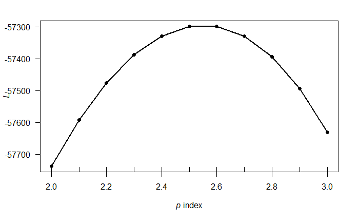

```r
start <- Sys.time()
# identity link
output <- tweedie.profile(PAID~1, data=AutoClaims, link.power=1,
                          method="interpolation", verbose=2,
                          do.plot=TRUE, do.smooth=FALSE,
                          p.vec=seq(2,3,.1))
```

```r
end <- Sys.time()
print(end-start)
```

```
Time difference of 28.46994 secs
```

```
---
 This function may take some time to complete;
 Please be patient.  If it fails, try using  method="series"
 rather than the default  method="inversion"
 Another possible reason for failure is the range of p:
 Try a different input for  p.vec
---
2 2.05 2.1 2.15 2.2 2.25 2.3 2.35 2.4 2.45 2.5 2.55 2.6 2.65 2.7 2.75 2.8 2.85 2.9 2.95 3
p = 2
* Fitting initial model: Done
* Phi estimation, method:  mle (using optimize):  Done (phi = 0.9871975 )
* Computing the log-likelihood (method = interpolation ): Done: L = -57736.62
p = 2.05
* Fitting initial model: Done
* Phi estimation, method:  mle (using optimize):  Done (phi = 0.6946015 )
* Computing the log-likelihood (method = interpolation ): Done: L = -57660.28
p = 2.1
* Fitting initial model: Done
* Phi estimation, method:  mle (using optimize):  Done (phi = 0.4892748 )
* Computing the log-likelihood (method = interpolation ): Done: L = -57591.43
p = 2.15
* Fitting initial model: Done
* Phi estimation, method:  mle (using optimize):  Done (phi = 0.3450782 )
* Computing the log-likelihood (method = interpolation ): Done: L = -57529.87
p = 2.2
* Fitting initial model: Done
* Phi estimation, method:  mle (using optimize):  Done (phi = 0.2437287 )
* Computing the log-likelihood (method = interpolation ): Done: L = -57475.47
p = 2.25
* Fitting initial model: Done
* Phi estimation, method:  mle (using optimize):  Done (phi = 0.1724133 )
* Computing the log-likelihood (method = interpolation ): Done: L = -57428.16
p = 2.3
* Fitting initial model: Done
* Phi estimation, method:  mle (using optimize):  Done (phi = 0.1221277 )
* Computing the log-likelihood (method = interpolation ): Done: L = -57387.91
p = 2.35
* Fitting initial model: Done
* Phi estimation, method:  mle (using optimize):  Done (phi = 0.08667572 )
* Computing the log-likelihood (method = interpolation ): Done: L = -57354.74
```

[output cut: 42 more lines]

```
* Phi estimation, method:  mle (using optimize):  Done (phi = 0.00231808 )
* Computing the log-likelihood (method = interpolation ): Done: L = -57492.9
p = 2.95
* Fitting initial model: Done
* Phi estimation, method:  mle (using optimize):  Done (phi = 0.00168758 )
* Computing the log-likelihood (method = interpolation ): Done: L = -57556.56
p = 3
* Fitting initial model: Done
* Phi estimation, method:  mle (using optimize):  Done (phi = 0.00122718 )
* Computing the log-likelihood (method = interpolation ): Done: L = -57630.13
 Some values of L are infinite or NA, and hence ignored
 Done
 Finding maximum likelihood estimates:   Done
ML Estimates:   p = 2.55  with phi= 0.0224406  giving L= -57294.39
 ---
```

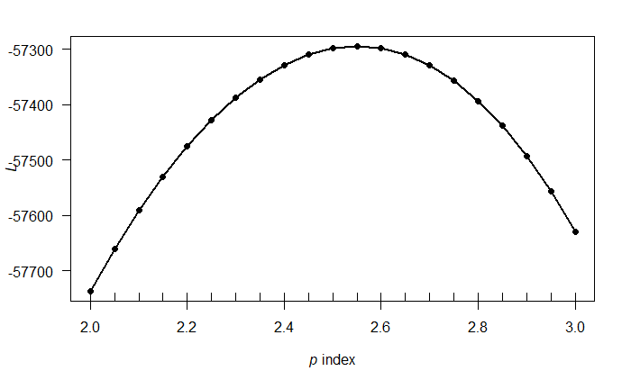

```r
start <- Sys.time()
# identity link
output <- tweedie.profile(PAID~1, data=AutoClaims, link.power=1,
                          method="interpolation", verbose=2,
                          do.plot=TRUE, do.smooth=FALSE,
                          p.vec=seq(2,3,.05))
```

```r
end <- Sys.time()
print(end-start)
```

```
Time difference of 54.7458 secs
```

```
---
 This function may take some time to complete;
 Please be patient.  If it fails, try using  method="series"
 rather than the default  method="inversion"
 Another possible reason for failure is the range of p:
 Try a different input for  p.vec
---
2 2.025 2.05 2.075 2.1 2.125 2.15 2.175 2.2 2.225 2.25 2.275 2.3 2.325 2.35 2.375 2.4 2.425 2.45 2.475 2.5 2.525 2.55 2.575 2.6 2.625 2.65 2.675 2.7 2.725 2.75 2.775 2.8 2.825 2.85 2.875 2.9 2.925 2.95 2.975 3
p = 2
* Fitting initial model: Done
* Phi estimation, method:  mle (using optimize):  Done (phi = 0.9871975 )
* Computing the log-likelihood (method = interpolation ): Done: L = -57736.62
p = 2.025
* Fitting initial model: Done
* Phi estimation, method:  mle (using optimize):  Done (phi = 0.827972 )
* Computing the log-likelihood (method = interpolation ): Done: L = -57697.5
p = 2.05
* Fitting initial model: Done
* Phi estimation, method:  mle (using optimize):  Done (phi = 0.6946028 )
* Computing the log-likelihood (method = interpolation ): Done: L = -57660.28
p = 2.075
* Fitting initial model: Done
* Phi estimation, method:  mle (using optimize):  Done (phi = 0.5828809 )
* Computing the log-likelihood (method = interpolation ): Done: L = -57624.93
p = 2.1
* Fitting initial model: Done
* Phi estimation, method:  mle (using optimize):  Done (phi = 0.4892755 )
* Computing the log-likelihood (method = interpolation ): Done: L = -57591.43
p = 2.125
* Fitting initial model: Done
* Phi estimation, method:  mle (using optimize):  Done (phi = 0.410836 )
* Computing the log-likelihood (method = interpolation ): Done: L = -57559.75
p = 2.15
* Fitting initial model: Done
* Phi estimation, method:  mle (using optimize):  Done (phi = 0.3450902 )
* Computing the log-likelihood (method = interpolation ): Done: L = -57529.87
p = 2.175
* Fitting initial model: Done
* Phi estimation, method:  mle (using optimize):  Done (phi = 0.289968 )
* Computing the log-likelihood (method = interpolation ): Done: L = -57501.78
```

[output cut: 122 more lines]

```
* Phi estimation, method:  mle (using optimize):  Done (phi = 0.00168003 )
* Computing the log-likelihood (method = interpolation ): Done: L = -57556.69
p = 2.975
* Fitting initial model: Done
* Phi estimation, method:  mle (using optimize):  Done (phi = 0.00143646 )
* Computing the log-likelihood (method = interpolation ): Done: L = -57592.14
p = 3
* Fitting initial model: Done
* Phi estimation, method:  mle (using optimize):  Done (phi = 0.001228326 )
* Computing the log-likelihood (method = interpolation ): Done: L = -57630.08
 Some values of L are infinite or NA, and hence ignored
 Done
 Finding maximum likelihood estimates:   Done
ML Estimates:   p = 2.55  with phi= 0.02243302  giving L= -57294.39
 ---
```

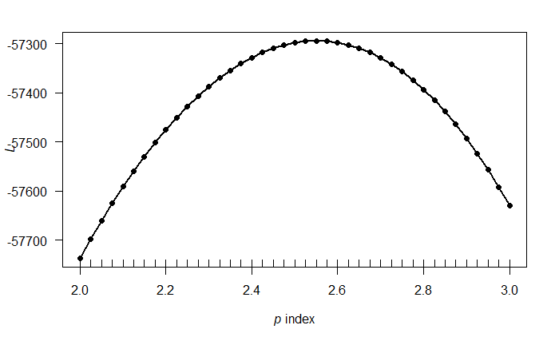

```r
start <- Sys.time()
# identity link
output <- tweedie.profile(PAID~1, data=AutoClaims, link.power=1,
                          method="interpolation", verbose=2,
                          do.plot=TRUE, do.smooth=FALSE,
                          p.vec=seq(2,3,.025))
```

```r
end <- Sys.time()
print(end-start)
```

```
Time difference of 1.798516 mins
```

Our approach says that p=2.55 and phi=.02243302. Notably, phi is very small. This probably has to do with the fact that mu is larger in this dataset. Variance is a function of mu, phi, and p.

Compare the gamma model to the Tweedie model with p=2.55.

Write some functions to get feedback.

```r
give_feedback <- function(model){
  SSR <- sum((model$residuals)**2)
  fitted_values <- model$fitted.values
  print("Squared Sum of Residuals"); print(SSR)
  print("Deviance"); print(model$deviance)
  print("AIC"); print(AICtweedie(model))
}
compare_insurance_models <- function(model1, model2){

  SSR1 <- sum((model1$residuals)**2)
  SSR2 <- sum((model2$residuals)**2)
  diff_SSR <- SSR1 - SSR2

  fitted_values1 <- model1$fitted.values
  fitted_values2 <- model2$fitted.values
  diff_fitted_values <- fitted_values1 - fitted_values2
  diff_losses <- sum(abs(diff_fitted_values))
  diff_econ = sum(model1$fitted.values - model2$fitted.values)

  diff_deviance <- model1$deviance - model2$deviance
  diff_AIC <- AICtweedie(model1) - AICtweedie(model2)

  print("Model differences are relative to the first model")
  print("Squared Sum of Residuals"); print(diff_SSR)
  print("Deviance"); print(diff_deviance)
  print("AIC"); print(diff_AIC)

  print("Sum of absolute differences between losses"); print(diff_losses)
  print("Total difference between losses"); print(diff_econ)

  print("First 10 differences in fitted losses")
  print(diff_fitted_values[1:5])

}
```

The gamma model is m3.

```r
give_feedback(m3)
```

```
[1] "Squared Sum of Residuals"
[1] 13428.95
[1] "Deviance"
[1] 7598.841
[1] "AIC"
[1] 115515.5
```

Make the Tweedie model with p=2.55.

```r
m4 <- glm(PAID~1+YEAR+CLASS+STATE, data=AutoClaims,
          family=tweedie(link.power=0,var.power=2.55))
give_feedback(m4)
```

```
[1] "Squared Sum of Residuals"
[1] 13431.01
[1] "Deviance"
[1] 159.441
[1] "AIC"
[1] 114592.8
```

```r
summary(m4)
```

```
Call:
glm(formula = PAID ~ 1 + YEAR + CLASS + STATE, family = tweedie(link.power = 0,
    var.power = 2.55), data = AutoClaims)

Deviance Residuals:
     Min        1Q    Median        3Q       Max
-0.78754  -0.14868  -0.07379   0.01899   0.78907

Coefficients:
               Estimate Std. Error t value Pr(>|t|)
(Intercept)    7.365467   0.117744  62.555  < 2e-16 ***
YEAR6         -0.034653   0.043115  -0.804  0.42158
YEAR7         -0.035245   0.062470  -0.564  0.57265
YEAR8          0.116700   0.079475   1.468  0.14205
YEAR9          0.204750   0.220582   0.928  0.35332
CLASSC11       0.009422   0.069074   0.136  0.89151
CLASSC1A      -0.053298   0.167493  -0.318  0.75034
CLASSC1B       0.027193   0.088249   0.308  0.75799
CLASSC1C      -0.233735   0.220267  -1.061  0.28866
CLASSC2       -0.323513   0.174793  -1.851  0.06424 .
CLASSC6        0.008277   0.082784   0.100  0.92036
CLASSC7       -0.007024   0.072110  -0.097  0.92241
CLASSC71       0.007637   0.070170   0.109  0.91333
CLASSC72       0.212179   0.170181   1.247  0.21252
CLASSC7A       0.038506   0.144723   0.266  0.79020
CLASSC7B       0.158464   0.079719   1.988  0.04688 *
CLASSC7C       0.176211   0.173033   1.018  0.30854
CLASSF1       -0.079816   0.259228  -0.308  0.75817
CLASSF11       0.159107   0.237672   0.669  0.50324
CLASSF6        0.026588   0.132863   0.200  0.84140
CLASSF7       -0.509204   0.166459  -3.059  0.00223 **
CLASSF71      -0.070103   0.152300  -0.460  0.64532
STATESTATE 02  0.115876   0.113569   1.020  0.30762
STATESTATE 03  0.121092   0.129549   0.935  0.34997
STATESTATE 04  0.063249   0.119366   0.530  0.59621
STATESTATE 06  0.266090   0.121260   2.194  0.02824 *
STATESTATE 07  0.192003   0.137859   1.393  0.16374
STATESTATE 10  0.167470   0.136224   1.229  0.21897
STATESTATE 11  0.108120   0.477824   0.226  0.82099
STATESTATE 12  0.400002   0.144079   2.776  0.00551 **
STATESTATE 13  0.224305   0.146291   1.533  0.12525
STATESTATE 14  0.062591   0.148971   0.420  0.67439
STATESTATE 15  0.087005   0.109938   0.791  0.42874
STATESTATE 17  0.219559   0.124994   1.757  0.07904 .
---
Signif. codes:  0 ‘***’ 0.001 ‘**’ 0.01 ‘*’ 0.05 ‘.’ 0.1 ‘ ’ 1

(Dispersion parameter for Tweedie family taken to be 0.03188236)

    Null deviance: 161.19  on 6772  degrees of freedom
Residual deviance: 159.44  on 6739  degrees of freedom
AIC: NA

Number of Fisher Scoring iterations: 9
```

Make the inverse-Gaussian model (p=3).

```r
m5 <- glm(PAID~1+YEAR+CLASS+STATE, data=AutoClaims,
          family=tweedie(link.power=0,var.power=3))
give_feedback(m5)
```

```
[1] "Squared Sum of Residuals"
[1] 13432.79
[1] "Deviance"
[1] 8.383859
[1] "AIC"
[1] 115280.9
```

```r
summary(m5)
```

```
Call:
glm(formula = PAID ~ 1 + YEAR + CLASS + STATE, family = tweedie(link.power = 0,
    var.power = 3), data = AutoClaims)

Deviance Residuals:
     Min        1Q    Median        3Q       Max
-0.32267  -0.03096  -0.01430   0.00345   0.12906

Coefficients:
               Estimate Std. Error t value Pr(>|t|)
(Intercept)    7.365669   0.114218  64.488  < 2e-16 ***
YEAR6         -0.035527   0.042897  -0.828 0.407588
YEAR7         -0.040303   0.061944  -0.651 0.515305
YEAR8          0.111713   0.080183   1.393 0.163599
YEAR9          0.201467   0.228212   0.883 0.377372
CLASSC11       0.010678   0.068871   0.155 0.876796
CLASSC1A      -0.050370   0.165965  -0.303 0.761519
CLASSC1B       0.025378   0.088531   0.287 0.774384
CLASSC1C      -0.245058   0.207541  -1.181 0.237735
CLASSC2       -0.325642   0.163975  -1.986 0.047082 *
CLASSC6        0.010581   0.082528   0.128 0.897988
CLASSC7       -0.008220   0.071685  -0.115 0.908714
CLASSC71       0.007513   0.069887   0.107 0.914400
CLASSC72       0.212427   0.176208   1.206 0.228035
CLASSC7A       0.032587   0.144765   0.225 0.821908
CLASSC7B       0.158495   0.080917   1.959 0.050184 .
CLASSC7C       0.167276   0.177619   0.942 0.346345
CLASSF1       -0.080799   0.252359  -0.320 0.748847
CLASSF11       0.174765   0.244550   0.715 0.474858
CLASSF6        0.032717   0.133070   0.246 0.805799
CLASSF7       -0.514969   0.148153  -3.476 0.000512 ***
CLASSF71      -0.068232   0.148678  -0.459 0.646301
STATESTATE 02  0.120913   0.109876   1.100 0.271176
STATESTATE 03  0.118835   0.126104   0.942 0.346045
STATESTATE 04  0.062529   0.115509   0.541 0.588298
STATESTATE 06  0.268018   0.118737   2.257 0.024025 *
STATESTATE 07  0.195442   0.135708   1.440 0.149865
STATESTATE 10  0.172713   0.133747   1.291 0.196629
STATESTATE 11  0.132449   0.477756   0.277 0.781611
STATESTATE 12  0.402787   0.145293   2.772 0.005582 **
STATESTATE 13  0.222944   0.144819   1.539 0.123737
STATESTATE 14  0.068256   0.144619   0.472 0.636965
STATESTATE 15  0.087041   0.106127   0.820 0.412155
STATESTATE 17  0.219925   0.122428   1.796 0.072481 .
---
Signif. codes:  0 ‘***’ 0.001 ‘**’ 0.01 ‘*’ 0.05 ‘.’ 0.1 ‘ ’ 1

(Dispersion parameter for Tweedie family taken to be 0.001085006)

    Null deviance: 8.4441  on 6772  degrees of freedom
Residual deviance: 8.3839  on 6739  degrees of freedom
AIC: NA

Number of Fisher Scoring iterations: 16
```

Compare p=2 and p=2.55 models.

```r
compare_insurance_models(m4,m3)
```

```
[1] "Model differences are relative to the first model"
[1] "Squared Sum of Residuals"
[1] 2.064116
[1] "Deviance"
[1] -7439.4
[1] "AIC"
[1] -922.7116
[1] "Sum of absolute differences between losses"
[1] 38776.8
[1] "Total difference between losses"
[1] 875.2139
[1] "First 10 differences in fitted losses"
        1         2         3         4         5
11.460139 -2.071820 -4.421738  8.667693  8.667693
```

Compare p=2.55 and p=3 models.

```r
compare_insurance_models(m4,m5)
```

```
[1] "Model differences are relative to the first model"
[1] "Squared Sum of Residuals"
[1] -1.778149
[1] "Deviance"
[1] 151.0572
[1] "AIC"
[1] -688.0772
[1] "Sum of absolute differences between losses"
[1] 33524.28
[1] "Total difference between losses"
[1] -2058.2
[1] "First 10 differences in fitted losses"
         1          2          3          4          5
-10.199699   1.580615   3.816685  -6.711550  -6.711550
```

Compare gamma and inverse-Gaussian models.

```r
compare_insurance_models(m5,m3)
```

```
[1] "Model differences are relative to the first model"
[1] "Squared Sum of Residuals"
[1] 3.842266
[1] "Deviance"
[1] -7590.457
[1] "AIC"
[1] -234.6344
[1] "Sum of absolute differences between losses"
[1] 72195.01
[1] "Total difference between losses"
[1] 2933.414
[1] "First 10 differences in fitted losses"
        1         2         3         4         5
21.659838 -3.652435 -8.238423 15.379243 15.379243
```

Take at a sneak peek at how fitted values change as p changes.

```r
m3$fitted.values[1:5]
```

```
       1        2        3        4        5
2070.543 2135.530 2140.323 2164.216 2164.216
```

```r
m4$fitted.values[1:5]
```

```
       1        2        3        4        5
2082.003 2133.459 2135.901 2172.883 2172.883
```

```r
m5$fitted.values[1:5]
```

```
       1        2        3        4        5
2092.203 2131.878 2132.084 2179.595 2179.595
```

Some observations. - Tweedie model with p=2.55 estimates a dispersion parameter close to what tweedie.profile gives. The gamm model estimates phi close to 2. - Tweedie model with p=2.55 has lower deviance and lower AIC. - We could improve our predictions by ~$38,777. - Differences in losses for individual observations is in the 10s. - We only have ~6K observations. - We get weird results for the deviance of the inverse-Gaussian model.

How much impact could changing the power parameter do to the modeling?

```r
38777/sum(AutoClaims$PAID)
```

```
[1] 0.003089652
```

Improving the model would barely change the total costs relative to how much loss is present. (I won’t highlight this notebook in my thesis.)

Again, optimizing the power parameter provided little change in the grand scheme of things.

```r
sum(m3$fitted.values)/sum(AutoClaims$PAID)
```

```
[1] 0.9999878
```

```r
sum(m4$fitted.values)/sum(AutoClaims$PAID)
```

```
[1] 1.000058
```

```r
sum(m5$fitted.values)/sum(AutoClaims$PAID)
```

```
[1] 1.000222
```